# final_project.Rmd

2026-11-09

## Final Project: Test I Can Run 11.16.26

Research Question and Progress

My main research question is: How did AEW Dynamite’s television viewership differ between periods when CM Punk was active, absent and no longer with AEW?

Following Professor Willis’s feedback on my initial data exploration, I’ve continued working with the 367 Dynamite television ratings records covering October 2019 through October 2026.

So far, I’ve calculated yearly averages and medians, examined the available data and created a line graph showing weekly television viewership. I’ve also begun identifying the different periods of CM Punk’s AEW tenure so I can compare the ratings more closely.

###Mean, Median and Standard Deviation

As Professor Willis previously recommended, one of my main priorities is comparing the mean, median and standard deviation of weekly viewership during Punk’s active, absent and post-AEW periods.

I think these measurements will be particularly useful because they can help me understand not only which periods had higher average viewership, but also how consistent the ratings were.

For example, two periods could have similar average audiences but very different fluctuations in weekly viewership. I also want to account for the number of episodes in each group since the periods aren’t all the same length.

###Examining Trends and Outliers

I’ve already created a line graph showing Dynamite’s weekly television viewership. My next goal is to use that graph alongside the different CM Punk periods to identify any noticeable changes.

We’ve previously worked with quartiles, the interquartile range and standard deviations. I think those concepts could help me identify episodes with unusually high or low viewership.

Something else I’m interested in is whether a few particularly successful episodes could influence the averages enough to make one period appear stronger than another.

###Statistical Significance and Confidence Intervals

Another analysis I’d like to explore is whether differences in average viewership between the periods are statistically significant.

We’ve worked with hypothesis testing, confidence intervals and p-values in previous assignments. I believe those methods could help me determine whether the differences I’m finding are substantial or potentially consistent with ordinary variation.

However, I’m not entirely sure which statistical test would work best for comparing three main groups: active, absent and no longer with AEW.

I’m particularly interested in whether a two-sample t-test could be useful for comparing individual periods or whether a different approach would be better for evaluating all three groups together.

I also wonder whether the fact that these are weekly television ratings, rather than independent random observations, affects which tests would be appropriate.

###Correlation and Linear Regression

After completing Homework 15, I also believe correlation and linear regression could be useful for my project.

In that assignment, I examined the relationship between GDP and the Dow Jones Industrial Average and learned more about interpreting scatter plots, regression lines and correlation coefficients.

For Dynamite, I could potentially use regression to examine whether television viewership generally increased or decreased over time.

I’m also interested in whether there’s a strong correlation between total television viewers and the adults 18–49 demographic ratings, since both variables are included in my dataset.

However, I recognize that these analyses might provide supporting information rather than directly answering my main research question.

###Limitations and Additional Questions

One challenge is that CM Punk’s presence or absence wasn’t the only factor that could influence AEW’s television ratings.

For example, Dynamite moved from TNT to TBS in January 2022. Changes in television viewing habits, competing programming and other factors could also influence the numbers.

Another consideration is that Punk’s availability with AEW didn’t necessarily mean he appeared on Dynamite every week. I want to make sure my comparison periods are clearly defined before making conclusions.

My biggest remaining question is whether comparing the averages alone will give me an accurate picture, especially since the ratings cover several years and may reflect broader changes in television viewership.

I would appreciate Professor Willis’s guidance on whether the hypothesis tests we’ve learned are appropriate for this kind of weekly data or whether regression could help account for some of those broader trends.

Ultimately, my goal is to determine whether measurable differences existed between the periods without automatically assuming CM Punk was responsible for those differences.

## Loading AEW Dynamite Television Ratings

```r
library(tidyverse)
library(jsonlite)

# Read the JSON without letting jsonlite guess the structure
ratings <- fromJSON("https://trnbckl.net/ratings.json", simplifyVector = FALSE)

# Helper: turn JSON nulls into NA so every record has the same shape
null_to_na <- function(x) map(x, \(v) if (is.null(v)) NA else v)

# Weekly episode records: show, air date, viewers, P18-49 rating, code, note
weekly <- ratings$weekly |>
  map(null_to_na) |>
  map(\(x) tibble(
    show        = x[[1]],
    air_date    = x[[2]],
    viewers     = x[[3]],
    demo_rating = x[[4]],
    code        = x[[5]],
    note        = x[[6]]
  )) |>
  list_rbind() |>
  mutate(
    air_date    = ymd(air_date),
    viewers     = as.numeric(viewers),
    demo_rating = as.numeric(demo_rating),
    year        = year(air_date)
  )

dynamite <- weekly |>
  filter(show == "Dynamite")

# Save a CSV copy so the analysis doesn't depend on the live site
write_csv(dynamite, "dynamite_weekly.csv")

# Annual averages, if she wants them for checking her own calculations
annual <- ratings$annual |>
  map(null_to_na) |>
  map(\(x) tibble(
    show     = x[[1]],
    year     = x[[2]],
    metric   = x[[3]],
    value    = as.numeric(x[[4]]),
    episodes = x[[5]],
    note     = x[[7]]
  )) |>
  list_rbind()
```

## Exploring the AEW Dynamite Data

```r
library(tidyverse)
dynamite_data <- read_csv("dynamite_weekly.csv")
glimpse(dynamite_data)
```

```
## Rows: 367
## Columns: 7
## $ show        <chr> "Dynamite", "Dynamite", "Dynamite", "Dynamite", "Dynamite"…
## $ air_date    <date> 2019-10-02, 2019-10-09, 2019-10-16, 2019-10-23, 2019-10-3…
## $ viewers     <dbl> 1409000, 1018000, 1014000, 963000, 759000, 822000, 957000,…
## $ demo_rating <dbl> 0.68, 0.46, 0.44, 0.45, 0.33, 0.35, 0.43, 0.39, 0.26, 0.32…
## $ code        <dbl> 49, 49, 49, 49, 50, 50, 50, 50, 50, 50, 50, 49, 51, 51, 51…
## $ note        <chr> "debut show", "1.140M with TruTV simulcast", NA, NA, NA, N…
## $ year        <dbl> 2019, 2019, 2019, 2019, 2019, 2019, 2019, 2019, 2019, 2019…
```

```r
dynamite_data |>
  summarize(
    episodes = n(),
    first_date = min(air_date, na.rm = TRUE),
    last_date = max(air_date, na.rm = TRUE),
    missing_viewers = sum(is.na(viewers))
  )
```

```
## # A tibble: 1 × 4
##   episodes first_date last_date  missing_viewers
##      <int> <date>     <date>               <int>
## 1      367 2019-10-02 2026-10-14               0
```

```r
dynamite_data |>
  group_by(year) |>
  summarize(
    episodes = n(),
    average_viewers = round(mean(viewers), 0),
    median_viewers = median(viewers)
  )
```

```
## # A tibble: 8 × 4
##    year episodes average_viewers median_viewers
##   <dbl>    <int>           <dbl>          <dbl>
## 1  2019       12          900833         872000
## 2  2020       54          806611         799000
## 3  2021       52          893173         886000
## 4  2022       52          955712         961500
## 5  2023       52          864327         858000
## 6  2024       52          701596         700000
## 7  2025       52          586538         600000
## 8  2026       41          657244         653000
```

## AEW Dynamite Data Exploration

### Data Source and Description

For my final project, I’m examining AEW Dynamite’s television viewership from its debut in October 2019 through 2026. Professor Willis provided code to help me load the ratings data into RStudio from https://trnbckl.net/ratings.json.

After filtering the data for Dynamite, I have 367 weekly records covering October 2, 2019, through October 14, 2026. Each record represents one episode. I also saved the data as a CSV file so I can continue working with it in RStudio.

### Important Columns

The columns I’ll focus on are air_date, viewers, demo_rating and year. These will help me examine viewership trends over time, compare annual averages and look at changes during CM Punk’s time with AEW. The note column may also help explain unusual episodes or ratings.

### Initial Findings

The annual averages show that viewership has changed quite a bit over the years. For example, Dynamite averaged approximately 956,000 viewers in 2022, compared with approximately 587,000 in 2025. However, I want to examine the weekly numbers before drawing conclusions.

### Missing Data and Limitations

None of the 367 records have missing viewer totals, but I still need to confirm whether every episode is included. The 2026 data ends in October, so that year is incomplete. Another limitation is that these are television ratings, not complete audience totals. HBO Max streaming viewership isn’t included.

### Questions I Still Have

Professor Willis has already suggested comparing AEW’s viewership during CM Punk’s tenure, including periods when he was absent. My next challenge is figuring out which statistical tests would best determine whether those differences were significant, rather than just normal week-to-week changes in viewership.

## Professor Willis’s Feedback — Final Project Data Exploration

Professor Willis’s feedback:

> This is in good shape. A couple of thoughts: your best question I think is this one - “How did AEW Dynamite’s television viewership differ between periods when CM Punk was active, absent, and no longer with AEW?”

> To do that, you need to define the time frame of CM Punk’s availability, and you’ll want to plot weekly viewership. For the periods you define you’ll want to calculate group means, medians and standard deviations, the basic building blocks of our work.

> Then we can talk about tests.

## AEW Dynamite Weekly Viewership

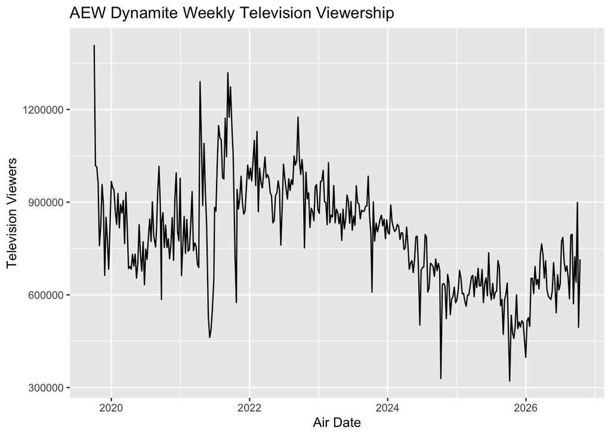

```r
ggplot(dynamite_data, aes(x = air_date, y = viewers)) +
  geom_line() +
  labs(
    title = "AEW Dynamite Weekly Television Viewership",
    x = "Air Date",
    y = "Television Viewers"
  )
```

## CM Punk Timeline for Viewership Comparisons

Before CM Punk: October 2, 2019 – August 18, 2021

CM Punk Active: August 25, 2021 – June 1, 2022 August 10, 2022 – August 31, 2022 June 21, 2023 – August 23, 2023

CM Punk Absent: June 8, 2022 – August 3, 2022 September 7, 2022 – June 14, 2023

Transition Period: August 30, 2023 – Review separately before classification.

After CM Punk’s Departure: September 6, 2023 – October 14, 2026

Note: These periods reflect CM Punk’s general availability with AEW, not necessarily appearances on Dynamite every week. ========

## CM Punk Viewership Analysis by Period

```r
library(tidyverse)
library(lubridate)

# Uses the existing dynamite_data dataframe.
dynamite_data <- dynamite_data |>
  mutate(
    air_date = as.Date(air_date),
    period = case_when(
      between(air_date, as.Date("2019-10-02"),
              as.Date("2021-08-18")) ~ "Before",

      between(air_date, as.Date("2021-08-25"),
              as.Date("2022-06-01")) |
      between(air_date, as.Date("2022-08-10"),
              as.Date("2022-08-31")) |
      between(air_date, as.Date("2023-06-21"),
              as.Date("2023-08-23")) ~ "Active",

      between(air_date, as.Date("2022-06-08"),
              as.Date("2022-08-03")) |
      between(air_date, as.Date("2022-09-07"),
              as.Date("2023-06-14")) ~ "Absent",

      air_date == as.Date("2023-08-30") ~ "Transition",

      air_date >= as.Date("2023-09-06") ~ "After",

      TRUE ~ NA_character_ )
  )
```

```r
 dynamite_data |>
  count(period)
```

```
## # A tibble: 5 × 2
##   period         n
##   <chr>      <int>
## 1 Absent        50
## 2 Active        55
## 3 After        162
## 4 Before        99
## 5 Transition     1
```

```r
dynamite_data |>
  group_by(period) |>
  summarize(
    episodes = n(),
    mean_viewers = round(mean(viewers, na.rm = TRUE), 0),
    median_viewers = median(viewers, na.rm = TRUE),
    sd_viewers = round(sd(viewers, na.rm = TRUE), 0)
  )
```

```
## # A tibble: 5 × 5
##   period     episodes mean_viewers median_viewers sd_viewers
##   <chr>         <int>        <dbl>          <dbl>      <dbl>
## 1 Absent           50       911640         902000      83380
## 2 Active           55       960345         954000     123609
## 3 After           162       667179         656500     115269
## 4 Before           99       828576         819000     154549
## 5 Transition        1       871000         871000         NA
```

```r
punk_comparison <- dynamite_data |>
  filter(period %in% c("Active", "Absent", "After"))

punk_anova <- aov(viewers ~ period, data = punk_comparison)

summary(punk_anova)
```

```
##              Df    Sum Sq   Mean Sq F value Pr(>F)
## period        2 4.706e+12 2.353e+12   187.9 <2e-16 ***
## Residuals   264 3.305e+12 1.252e+10
## ---
## Signif. codes:  0 '***' 0.001 '**' 0.01 '*' 0.05 '.' 0.1 ' ' 1
```

###So…what do we see exactly now that we’ve done the ANOVA test?

An ANOVA comparing Dynamite’s average viewership during CM Punk’s active, absent and post-departure periods found a statistically significant difference among the three groups (F = 187.9, p < 0.001). However, this test alone does not establish which groups differed or whether Punk’s presence caused the changes.

Professor Willis mentioned Tukey’s test earlier in the semester. I’m using it here to determine which specific periods had statistically significant differences in average viewership.

```r
TukeyHSD(punk_anova)
```

```
##   Tukey multiple comparisons of means
##     95% family-wise confidence level
##
## Fit: aov(formula = viewers ~ period, data = punk_comparison)
##
## $period
##                     diff         lwr       upr     p adj
## Active-Absent   48705.45   -2825.704  100236.6 0.0684109
## After-Absent  -244460.99 -287125.523 -201796.5 0.0000000
## After-Active  -293166.44 -334322.391 -252010.5 0.0000000
```

###To visualize the period comparisons more clearly, I created a bar chart below showing average weekly Dynamite viewership during the before, active, absent and after periods. This makes it easier to see that average viewership was highest during Punk’s active period, remained relatively strong during his absences, and dropped noticeably after his departure.**

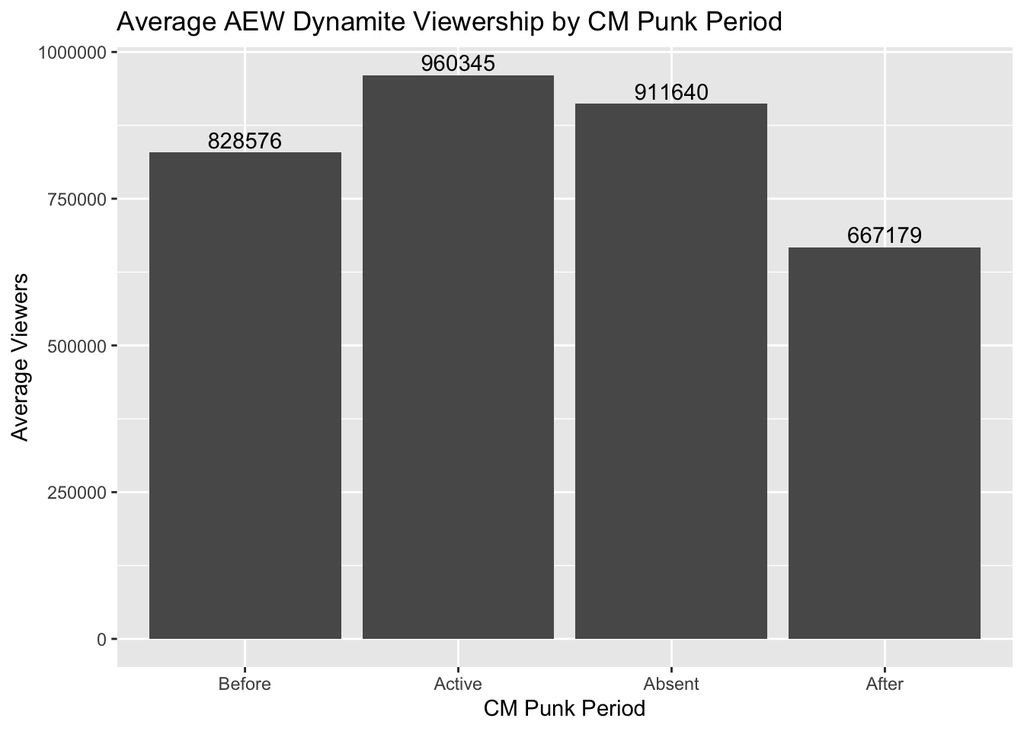

```r
plot_data <- dynamite_data |>
  filter(period %in% c("Before", "Active", "Absent", "After")) |>
  mutate(period = factor(period, levels = c("Before", "Active", "Absent", "After"))) |>
  group_by(period) |>
  summarize(
    mean_viewers = round(mean(viewers, na.rm = TRUE), 0)
  )

ggplot(plot_data, aes(x = period, y = mean_viewers)) +
  geom_col() +
  geom_text(aes(label = mean_viewers), vjust = -0.3) +
  labs(
    title = "Average AEW Dynamite Viewership by CM Punk Period",
    x = "CM Punk Period",
    y = "Average Viewers"
  )
```

### Making sense of what we’re seeing from the ggplot data graph

The graph shows that Dynamite averaged its highest viewership during CM Punk’s active periods, with 960,345 viewers per episode. Viewership remained relatively strong during his absences, averaging 911,640 viewers. However, after Punk’s departure, the average dropped to 667,179 viewers.

While the decline is noticeable, the graph alone doesn’t tell us whether Punk’s departure caused it. We still need to account for how Dynamite’s ratings changed over time.

### Regression Analysis: Accounting for Changes in Viewership Over Time

Professor Willis recommended using regression to see whether CM Punk’s status was associated with Dynamite’s viewership after accounting for changes over time. Unlike the ANOVA and Tukey tests, this analysis will include both the CM Punk periods and the passage of time. I want to see whether the differences we found earlier remain after considering the show’s overall viewership trend.

```r
punk_comparison <- punk_comparison |>
  mutate(
    weeks_since_start = as.numeric(air_date - min(air_date)) / 7,
    period = factor(period, levels = c("Active", "Absent", "After"))
  )

punk_regression <- lm(
  viewers ~ weeks_since_start + period,
  data = punk_comparison
)

summary(punk_regression)
```

```
##
## Call:
## lm(formula = viewers ~ weeks_since_start + period, data = punk_comparison)
##
## Residuals:
##     Min      1Q  Median      3Q     Max
## -421541  -56461   -4098   62758  333061
##
## Coefficients:
##                   Estimate Std. Error t value Pr(>|t|)
## (Intercept)        1007309      14536  69.299  < 2e-16 ***
## weeks_since_start    -1278        152  -8.407 2.68e-15 ***
## periodAbsent         -7804      20046  -0.389 0.697380
## periodAfter        -101545      27581  -3.682 0.000281 ***
## ---
## Signif. codes:  0 '***' 0.001 '**' 0.01 '*' 0.05 '.' 0.1 ' ' 1
##
## Residual standard error: 99520 on 263 degrees of freedom
## Multiple R-squared:  0.6748, Adjusted R-squared:  0.6711
## F-statistic: 181.9 on 3 and 263 DF,  p-value: < 2.2e-16
```

### Making Sense of the Regression Results

The regression changed how I looked at Dynamite’s viewership numbers. Earlier, we found that Dynamite averaged about 293,166 fewer viewers after CM Punk left AEW compared with his active periods. However, once I accounted for time, that difference dropped to about 101,545 viewers. The difference was still statistically significant (p < 0.001), but it wasn’t nearly as large as it first appeared.

Another thing that stood out was the overall decline in ratings. The model estimated that Dynamite lost approximately 1,278 viewers per week, even after accounting for Punk’s status. Meanwhile, the difference between his active and absent periods was only about 7,804 viewers after accounting for time, and that wasn’t statistically significant (p = 0.6974).

The model explained about 67% of the variation in weekly viewership. What I’m taking away from this is that AEW’s ratings were affected by a broader downward trend. While viewership was significantly lower after Punk left, these numbers alone don’t prove his departure was responsible. There’s more to the story than whether Punk was with the company.